# InClass04_join_ptt

Jilung Hsieh

9/22/2019

# 1 Loading libraries

```r
library(tidyverse)
options(stringsAsFactors = F)
```

# 2 Loading data

```r
load("data/HatePolitics_Hang_20190101_2019_06_01.rda")
```

# 3 Filtering posts by year >= 2019

```r
library(lubridate)
posts2019 <- posts %>% filter(year(ptime) >= 2019)
```

# 4 Filter comments by selected posts (year >= 2019)

```r
comments2019 <- comments %>% right_join(posts2019, by = "plink")
```

# 5 Filter posts with title category [新聞]

```r
posts %>% filter(str_detect(ptitle, "^\\[新聞\\]")) %>% head %>% knitr::kable()
```

[output not shown]

# 6 Computing number of comments of selected posts

- computing number of comments of posts with tilte starting with [新聞]

```r
comments %>%
    count(plink) %>%
    right_join(posts, by = "plink") %>%
    filter(str_detect(ptitle, "^\\[新聞\\]")) %>% head %>% knitr::kable()
```

[output not shown]

# 7 Computing number of comments for each post

```r
comments %>%
    count(plink) %>%
    right_join(posts, by = "plink") %>%
    filter(str_detect(ptitle, "^Re"))  %>% head %>% knitr::kable()
```

[output not shown]

[output not shown]

[output not shown]

# 8 Computer comment times to poster, each post counts one time.

```r
posts %>% select(plink, poster) %>%
    left_join(comments, by = "plink") %>%
    group_by(plink) %>%
    filter(!duplicated(commentor)) %>%
    ungroup() %>%
    count(commentor, poster, sort = T) %>%
    filter(!poster == "mark2165")  %>% head %>% knitr::kable()
```

| commentor | poster | n |
| --- | --- | --- |
| gn02118620 | gn02118620 | 64 |
| aylao | Mikolee | 56 |
| pupu20317 | Fed | 48 |
| ninaman | Mikolee | 46 |
| aylao | momo28 | 45 |
| ninaman | momo28 | 44 |

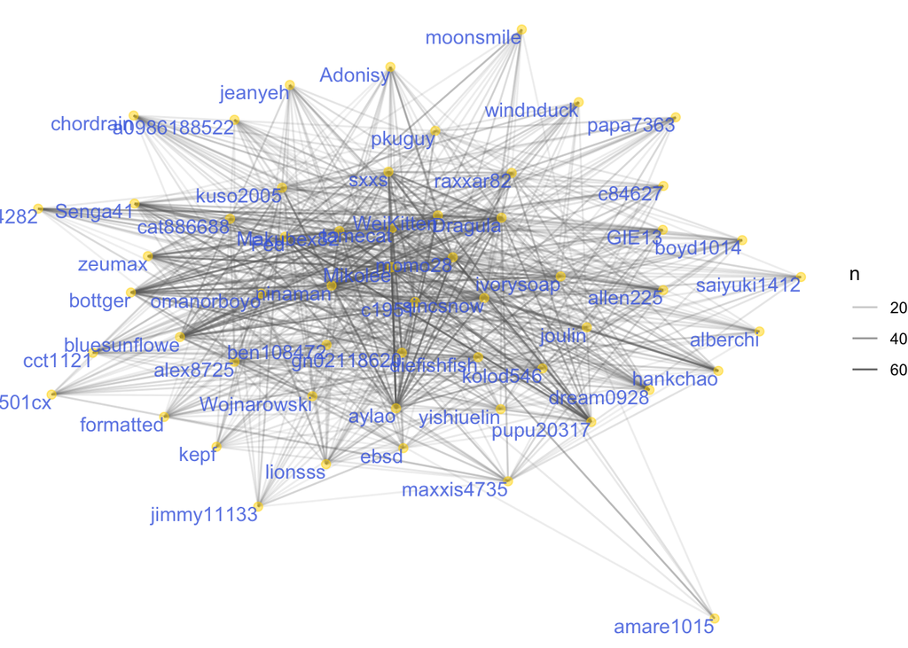

```r
library(igraph)
library(ggraph)
posts %>% select(plink, poster) %>%
    left_join(comments, by = "plink") %>%
    group_by(plink) %>%
    filter(!duplicated(commentor)) %>%
    ungroup() %>%
    filter(!poster == "mark2165") %>%
    count(commentor, poster, sort = T) %>%
    slice(1:3000) %>%
    group_by(commentor) %>%
    filter(n() >= 20) %>%
    ungroup() %>%
    group_by(poster) %>%
    filter(n() >= 20) %>%
    ungroup() %>%
    graph_from_data_frame(directed = T) %>%
    ggraph(layout = "fr") +
    geom_edge_link(aes(edge_alpha = n), color="dimgray") +
    geom_node_point(color = "gold", size = 2, alpha=0.5) +
    geom_node_text(aes(label = name), vjust = 1, hjust = 1, color = "royalblue", alpha = 0.8) +
    theme_void()
```